# Data Analysis for Storm Dataset

Stanley Lam

December 22, 2017

## 1. Synopsis

This is a data analysis on the storm dataset. The primary target is to find out (1) the types of events which are the most harmful with respect to population health, & (2) the types of events which have the greatest economic consequences. For the most harmful events, the total number of fatalities and injuries are calculated and the top 10 types of events are found and displayed in bar plots. Then the total property damage and the crop damage are calculated and considered to be the total economic consequence resulted from the events. Again, top 10 types of events are found and displayed in a stack bar plot.

## 2. Data Processing

#### Read the bz2 storm data file

```r
stormDat <- read.csv("data/repdata%2Fdata%2FStormData.csv.bz2")
```

#### Look at some basic info of the dataset

```r
head(stormDat)
```

```
##   STATE__           BGN_DATE BGN_TIME TIME_ZONE COUNTY COUNTYNAME STATE
## 1       1  4/18/1950 0:00:00     0130       CST     97     MOBILE    AL
## 2       1  4/18/1950 0:00:00     0145       CST      3    BALDWIN    AL
## 3       1  2/20/1951 0:00:00     1600       CST     57    FAYETTE    AL
## 4       1   6/8/1951 0:00:00     0900       CST     89    MADISON    AL
## 5       1 11/15/1951 0:00:00     1500       CST     43    CULLMAN    AL
## 6       1 11/15/1951 0:00:00     2000       CST     77 LAUDERDALE    AL
##    EVTYPE BGN_RANGE BGN_AZI BGN_LOCATI END_DATE END_TIME COUNTY_END
## 1 TORNADO         0                                               0
## 2 TORNADO         0                                               0
## 3 TORNADO         0                                               0
## 4 TORNADO         0                                               0
## 5 TORNADO         0                                               0
## 6 TORNADO         0                                               0
##   COUNTYENDN END_RANGE END_AZI END_LOCATI LENGTH WIDTH F MAG FATALITIES
```

[output cut: 20 more lines]

```r
str(stormDat)
```

```
## 'data.frame':    902297 obs. of  37 variables:
##  $ STATE__   : num  1 1 1 1 1 1 1 1 1 1 ...
##  $ BGN_DATE  : Factor w/ 16335 levels "1/1/1966 0:00:00",..: 6523 6523 4242 11116 2224 2224 2260 383 3980 3980 ...
##  $ BGN_TIME  : Factor w/ 3608 levels "00:00:00 AM",..: 272 287 2705 1683 2584 3186 242 1683 3186 3186 ...
##  $ TIME_ZONE : Factor w/ 22 levels "ADT","AKS","AST",..: 7 7 7 7 7 7 7 7 7 7 ...
##  $ COUNTY    : num  97 3 57 89 43 77 9 123 125 57 ...
##  $ COUNTYNAME: Factor w/ 29601 levels "","5NM E OF MACKINAC BRIDGE TO PRESQUE ISLE LT MI",..: 13513 1873 4598 10592 4372 10094 1973 23873 24418 4598 ...
##  $ STATE     : Factor w/ 72 levels "AK","AL","AM",..: 2 2 2 2 2 2 2 2 2 2 ...
##  $ EVTYPE    : Factor w/ 985 levels "   HIGH SURF ADVISORY",..: 834 834 834 834 834 834 834 834 834 834 ...
##  $ BGN_RANGE : num  0 0 0 0 0 0 0 0 0 0 ...
##  $ BGN_AZI   : Factor w/ 35 levels "","  N"," NW",..: 1 1 1 1 1 1 1 1 1 1 ...
##  $ BGN_LOCATI: Factor w/ 54429 levels "","- 1 N Albion",..: 1 1 1 1 1 1 1 1 1 1 ...
##  $ END_DATE  : Factor w/ 6663 levels "","1/1/1993 0:00:00",..: 1 1 1 1 1 1 1 1 1 1 ...
##  $ END_TIME  : Factor w/ 3647 levels ""," 0900CST",..: 1 1 1 1 1 1 1 1 1 1 ...
##  $ COUNTY_END: num  0 0 0 0 0 0 0 0 0 0 ...
```

[output cut: 23 more lines]

```r
names(stormDat)
```

```
##  [1] "STATE__"    "BGN_DATE"   "BGN_TIME"   "TIME_ZONE"  "COUNTY"
##  [6] "COUNTYNAME" "STATE"      "EVTYPE"     "BGN_RANGE"  "BGN_AZI"
## [11] "BGN_LOCATI" "END_DATE"   "END_TIME"   "COUNTY_END" "COUNTYENDN"
## [16] "END_RANGE"  "END_AZI"    "END_LOCATI" "LENGTH"     "WIDTH"
## [21] "F"          "MAG"        "FATALITIES" "INJURIES"   "PROPDMG"
## [26] "PROPDMGEXP" "CROPDMG"    "CROPDMGEXP" "WFO"        "STATEOFFIC"
## [31] "ZONENAMES"  "LATITUDE"   "LONGITUDE"  "LATITUDE_E" "LONGITUDE_"
## [36] "REMARKS"    "REFNUM"
```

#### Extract the essential subset of dataset & remove the storm dataset

```r
stormSub = subset(stormDat, select=c(EVTYPE,FATALITIES,INJURIES,PROPDMG,PROPDMGEXP,CROPDMG,CROPDMGEXP))
rm(stormDat)
```

#### Find the top 10 types of events that caused the most fatalities & injuries

```r
fatalsum <- aggregate(FATALITIES ~ EVTYPE, data = stormSub, FUN = sum)
fataltop10 <- fatalsum[order(fatalsum$FATALITIES, decreasing=T),][1:10,]
fataltop10$EVTYPE <- factor(fataltop10$EVTYPE, levels=as.character(fataltop10$EVTYPE))

injurysum <- aggregate(INJURIES ~ EVTYPE, data = stormSub, FUN = sum)
injurytop10 <- injurysum[order(injurysum$INJURIES, decreasing=T),][1:10,]
injurytop10$EVTYPE <- factor(injurytop10$EVTYPE, levels=as.character(injurytop10$EVTYPE))
```

#### Adjust the damage value by the exponential symbols (eg. H=100, K=1000, M=1000000)

```r
EXP <- c("h","H","k","K","M","m","B","0","1","2","3","4","5","6","7","8","","+","-","?")
VAL <- c(1e+02,1e+02,1e+03,1e+03,1e+06,1e+06,1e+09,1e+00,1e+01,1e+02,1e+03,1e+04,1e+05,1e+06,1e+07,1e+08,1e+00,1e+00,1e+00,1e+00)
for (i in 1:length(EXP)) {
  stormSub$pde[stormSub$PROPDMGEXP==EXP[i]] <- VAL[i]
  stormSub$cde[stormSub$CROPDMGEXP==EXP[i]] <- VAL[i]
}
stormSub$pdv <- stormSub$PROPDMG * stormSub$pde
stormSub$cdv <- stormSub$CROPDMG * stormSub$cde
```

#### Calculate the total economic damage (property + crop)

```r
econdmg <- merge(aggregate(pdv~EVTYPE, data=stormSub, FUN=sum),
                 aggregate(cdv~EVTYPE, data=stormSub, FUN=sum),
                 by="EVTYPE")
econdmg$sum <- econdmg$pdv+econdmg$cdv
```

#### Find the top 10 types of events of economic damage

```r
top10 <- econdmg[order(econdmg$sum, decreasing=T),][1:10,]
top10$EVTYPE <- factor(top10$EVTYPE, levels=as.character(top10$EVTYPE))
top10long <- with(top10, rbind(
  data.frame(Event_Type=EVTYPE, Damage_Type=as.factor("Crop Damage"), Damage_Value=cdv),
  data.frame(Event_Type=EVTYPE, Damage_Type=as.factor("Property Damage"), Damage_Value=pdv)))
```

## 3. Results

#### A. Plot the top 10 types of events for fatalities

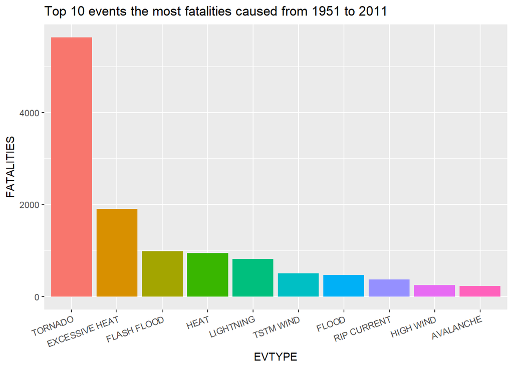

```r
library(ggplot2)
ggplot(data=fataltop10, aes(x=EVTYPE, y=FATALITIES, fill=EVTYPE))+geom_bar(stat="identity")+
  theme(axis.text.x = element_text(angle = 20, hjust = 1), legend.position="none")+
  ggtitle("Top 10 events the most fatalities caused from 1951 to 2011")
```

#### B. Plot the top 10 types of events for injuries

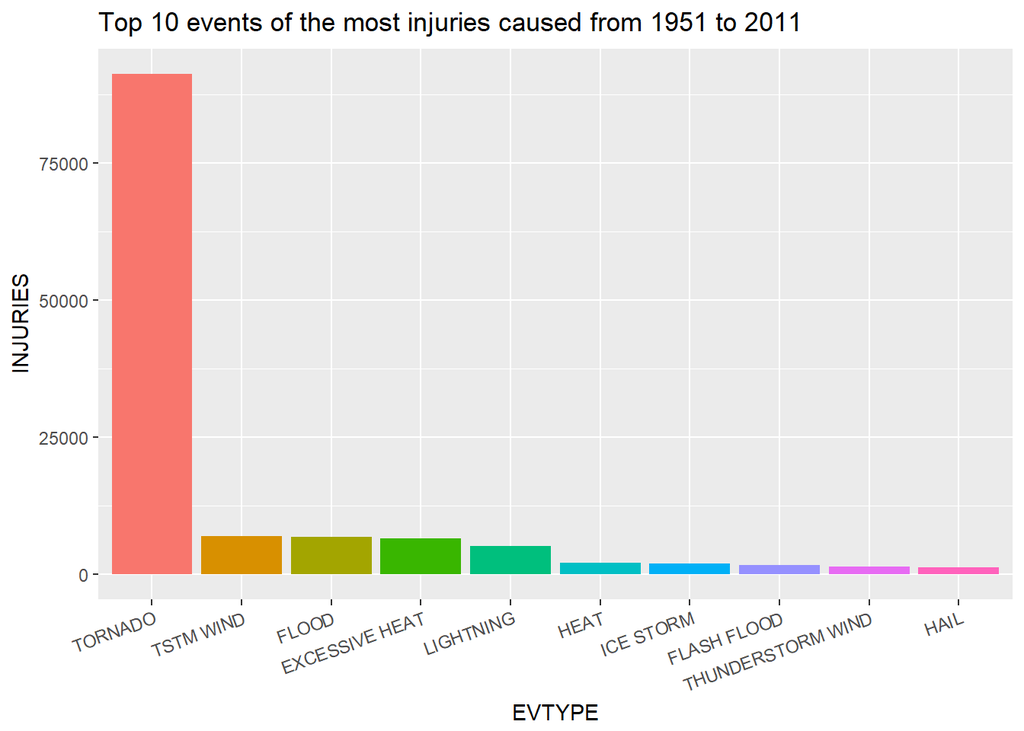

```r
ggplot(data=injurytop10, aes(x=EVTYPE, y=INJURIES, fill=EVTYPE))+geom_bar(stat="identity")+
  theme(axis.text.x = element_text(angle = 20, hjust = 1), legend.position="none")+
  ggtitle("Top 10 events of the most injuries caused from 1951 to 2011")
```

#### C. Plot a stack bar plot of the top 10 types of events that caused the greatest economic consequences

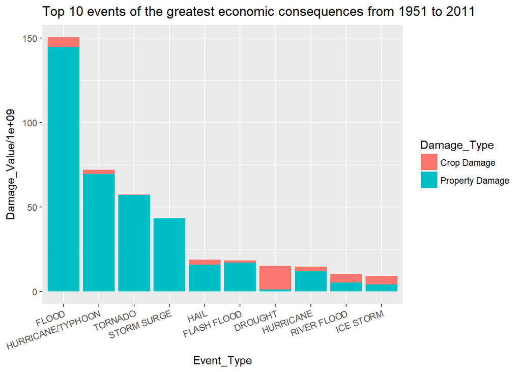

```r
ggplot(data=top10long,aes(x=Event_Type,y=Damage_Value/1e+09,fill=Damage_Type))+
  geom_bar(stat = "identity")+
  theme(axis.text.x = element_text(angle = 20, hjust = 1))+
  ggtitle("Top 10 events of the greatest economic consequences from 1951 to 2011")
```